# W3cubDocs

## Update the application

### Count the letters in your name

1. Open the file `Main.kt` in `src/nativeMain/kotlin`.

   The `src` directory contains the Kotlin source files and resources. The file `Main.kt` includes sample code that prints "Hello, Kotlin/Native!" using the `println()` function.
2. Add code to read the input. Use the `readln()` function to read the input value and assign it to the `name` variable:

   ```
   fun main() {
       // Read the input value.
       println("Hello, enter your name:")
       val name = readln()
   }
   ```

3. Eliminate the whitespaces and count the letters:
   - Use the `replace()` function to remove the empty spaces in the name.
   - Use the scope function `let` to run the function within the object context.
   - Use a string template to insert your name length into the string by adding a dollar sign `$` and enclosing it in curly braces – `${it.length}`. `it` is the default name of a lambda parameter.

   ```
   fun main() {
       // Read the input value.
       println("Hello, enter your name:")
       val name = readln()
       // Count the letters in the name.
       name.replace(" ", "").let {
           println("Your name contains ${it.length} letters")
       }
   }
   ```

4. Save the changes and run the following command in the IntelliJ IDEA terminal or your command-line tool:

   ```
   build/bin/native/debugExecutable/<your_app_name>.kexe
   ```

5. Enter your name and enjoy the result:

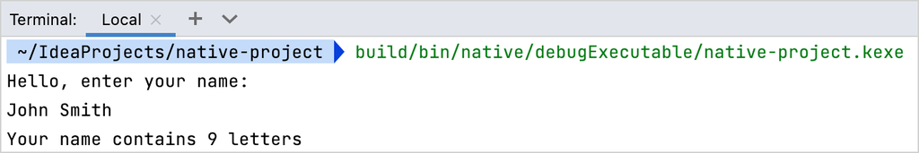

### Count the unique letters in your name

1. Open the file `Main.kt` in `src/nativeMain/kotlin`.
2. Declare the new extension function `countDistinctCharacters()` for `String`:
   - Convert the name to lowercase using the `lowercase()` function.
   - Convert the input string to a list of characters using the `toList()` function.
   - Select only the distinct characters in your name using the `distinct()` function.
   - Count the distinct characters using the `count()` function.

   ```
   fun String.countDistinctCharacters() = lowercase().toList().distinct().count()
   ```

3. Use the `countDistinctCharacters()` function to count the unique letters in your name:

   ```
   fun String.countDistinctCharacters() = lowercase().toList().distinct().count()

   fun main() {
       // Read the input value.
       println("Hello, enter your name:")
       val name = readln()
       // Count the letters in the name.
       name.replace(" ", "").let {
           println("Your name contains ${it.length} letters")
           // Print the number of unique letters.
           println("Your name contains ${it.countDistinctCharacters()} unique letters")
       }
   }
   ```

4. Save the changes and run the following command in the IntelliJ IDEA terminal or your command-line tool:

   ```
   build/bin/native/debugExecutable/<your_app_name>.kexe
   ```

5. Enter your name and enjoy the result:

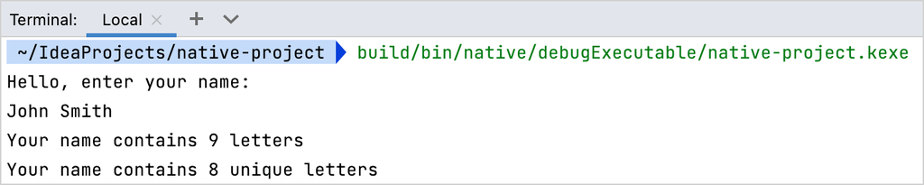

## What's next?

Once you have created your first application, you can complete our long-form tutorial on Kotlin/Native, Create an app using C Interop and libcurl that explains how to create a native HTTP client and interoperate with C libraries.

Last modified: 21 June 2023

© 2010–2023 JetBrains s.r.o. and Kotlin Programming Language contributors  
Licensed under the Apache License, Version 2.0.  
https://kotlinlang.org/docs/native-get-started.html